# DTSA5510 Final Project

## DTSA5510: Introduction to Unsupervised Machine Learning

### Final Project, 2023-10-15

### Problem Description:

I found a wine dataset on Kaggle, which is adapted from the University of California Irvine Machine Learning Repository. From the UCI description, "These data are the results of a chemical analysis of wines grown in the same region in Italy but derived from three different cultivars. The analysis determined the quantities of 13 constituents found in each of the three types of wines. The attributes are: Alcohol, Malic acid, Ash, Alcalinity of Ash, Magnesium, Total phenols, Flavanoids, Nonflavanoid phenols, Proanthocyanins, Color intensity, Hue, OD280/OD315 of diluted wines, and Proline.

This project will attempt to classify each wine into one of the three types using the chemical analysis information given. The primary analysis will use K-means clustering, then perform Principal Components Analysis and see if the K-means clustering results improve.

This dataset does not have labels, so I will be assessing the KMeans results by comparing inertia, as well as visually assessing the groupings.

The wine dataset can be found on Kaggle [here](https://www.kaggle.com/datasets/harrywang/wine-dataset-for-clustering/data).

### Exploratory Data Analysis

```python
## Import libraries

import pandas as pd
import numpy as np
import matplotlib.pyplot as plt
# statsmodels.formula.api as smf
#import statsmodels.api as sm
#import sklearn
from sklearn.model_selection import train_test_split
from sklearn import preprocessing
from sklearn import metrics
from sklearn import cluster
from sklearn.decomposition import PCA
import seaborn as sns
```

```python
## Load dataset

wine_data = pd.read_csv('C:/Users/kathe/OneDrive/MS-DS/DTSA5510 - Unsupervised Machine Learning/Final Project/wine-clustering.csv',
                   sep = ',')
```

```python
wine_data.head()
```

|  | Alcohol | Malic_Acid | Ash | Ash_Alcanity | Magnesium | Total_Phenols | Flavanoids | Nonflavanoid_Phenols | Proanthocyanins | Color_Intensity | Hue | OD280 | Proline |
| --- | --- | --- | --- | --- | --- | --- | --- | --- | --- | --- | --- | --- | --- |
| 0 | 14.23 | 1.71 | 2.43 | 15.6 | 127 | 2.80 | 3.06 | 0.28 | 2.29 | 5.64 | 1.04 | 3.92 | 1065 |
| 1 | 13.20 | 1.78 | 2.14 | 11.2 | 100 | 2.65 | 2.76 | 0.26 | 1.28 | 4.38 | 1.05 | 3.40 | 1050 |
| 2 | 13.16 | 2.36 | 2.67 | 18.6 | 101 | 2.80 | 3.24 | 0.30 | 2.81 | 5.68 | 1.03 | 3.17 | 1185 |
| 3 | 14.37 | 1.95 | 2.50 | 16.8 | 113 | 3.85 | 3.49 | 0.24 | 2.18 | 7.80 | 0.86 | 3.45 | 1480 |
| 4 | 13.24 | 2.59 | 2.87 | 21.0 | 118 | 2.80 | 2.69 | 0.39 | 1.82 | 4.32 | 1.04 | 2.93 | 735 |

```python
wine_data.info()
```

```
<class 'pandas.core.frame.DataFrame'>
RangeIndex: 178 entries, 0 to 177
Data columns (total 13 columns):
 #   Column                Non-Null Count  Dtype
---  ------                --------------  -----
 0   Alcohol               178 non-null    float64
 1   Malic_Acid            178 non-null    float64
 2   Ash                   178 non-null    float64
 3   Ash_Alcanity          178 non-null    float64
 4   Magnesium             178 non-null    int64
 5   Total_Phenols         178 non-null    float64
 6   Flavanoids            178 non-null    float64
 7   Nonflavanoid_Phenols  178 non-null    float64
 8   Proanthocyanins       178 non-null    float64
 9   Color_Intensity       178 non-null    float64
 10  Hue                   178 non-null    float64
 11  OD280                 178 non-null    float64
 12  Proline               178 non-null    int64
dtypes: float64(11), int64(2)
memory usage: 18.2 KB
```

There are 178 wines in the dataset, and none of the chemical properties appear to be null. I will plot histograms of each characteristic to see the distribution of values. I will also look at a correlation matrix of the properties, as I imagine some of these may be related.

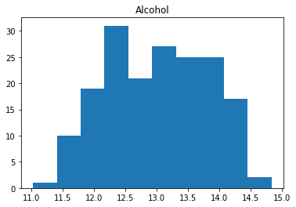

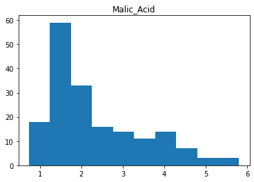

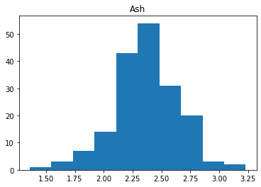

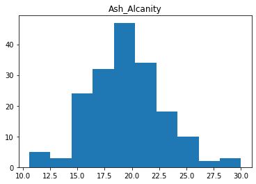

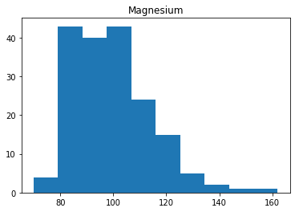

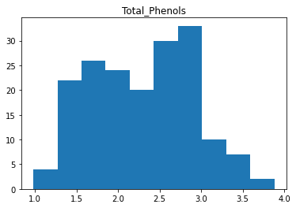

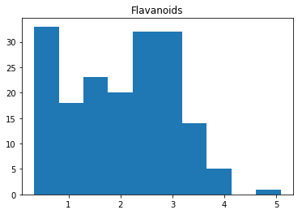

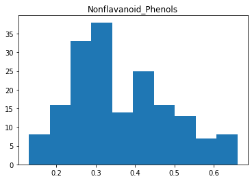

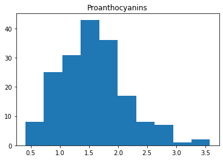

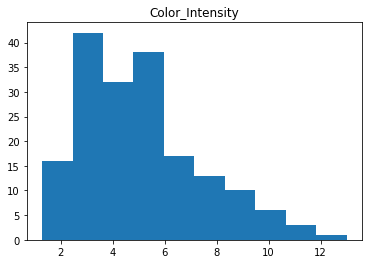

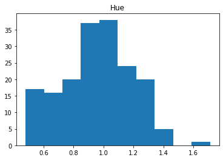

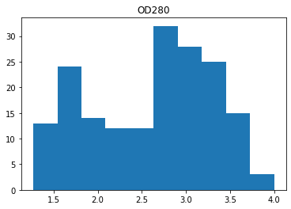

[1 more figures not shown]

```python
## Plot histogram of each feature

for col in wine_data.columns.tolist():
    plt.hist(wine_data[col])
    plt.title(col)
    plt.show()
```

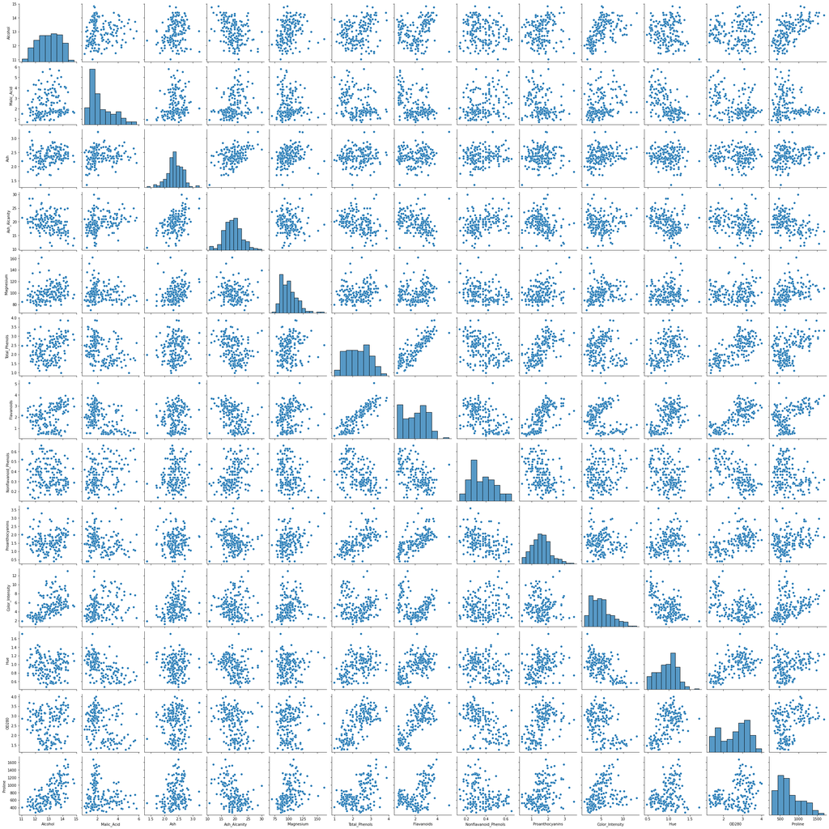

```python
sns.pairplot(wine_data)
```

In the correlation plot above, the strongest correlation appears to be between Flavonoids and Total Phenols. After a quick google search, this makes sense because flavonoids are phenolic compounds, and should be represented within the Total Phenols count.

The initial histograms confirm that there are no null values and don't appear to be any major outliers. Many features look to have a roughly normal distribution. My initial expectation is that the clusters of wines will become evident in the features that have a multi-modal distribution, such as non-flavonoid phenols and OD280.

Since several of the features appear to show a roughly normal distribution, I will use the standard scaler to normalize the data for different orders of magnitudes.

```python
## Feature scaling

scaler = preprocessing.StandardScaler().fit(wine_data)

wine_scaled = pd.DataFrame(data = scaler.transform(wine_data), columns = wine_data.columns)


wine_scaled.head()
```

|  | Alcohol | Malic_Acid | Ash | Ash_Alcanity | Magnesium | Total_Phenols | Flavanoids | Nonflavanoid_Phenols | Proanthocyanins | Color_Intensity | Hue | OD280 | Proline |
| --- | --- | --- | --- | --- | --- | --- | --- | --- | --- | --- | --- | --- | --- |
| 0 | 1.518613 | -0.562250 | 0.232053 | -1.169593 | 1.913905 | 0.808997 | 1.034819 | -0.659563 | 1.224884 | 0.251717 | 0.362177 | 1.847920 | 1.013009 |
| 1 | 0.246290 | -0.499413 | -0.827996 | -2.490847 | 0.018145 | 0.568648 | 0.733629 | -0.820719 | -0.544721 | -0.293321 | 0.406051 | 1.113449 | 0.965242 |
| 2 | 0.196879 | 0.021231 | 1.109334 | -0.268738 | 0.088358 | 0.808997 | 1.215533 | -0.498407 | 2.135968 | 0.269020 | 0.318304 | 0.788587 | 1.395148 |
| 3 | 1.691550 | -0.346811 | 0.487926 | -0.809251 | 0.930918 | 2.491446 | 1.466525 | -0.981875 | 1.032155 | 1.186068 | -0.427544 | 1.184071 | 2.334574 |
| 4 | 0.295700 | 0.227694 | 1.840403 | 0.451946 | 1.281985 | 0.808997 | 0.663351 | 0.226796 | 0.401404 | -0.319276 | 0.362177 | 0.449601 | -0.037874 |

### KMeans Clustering

Knowing that there are 3 wine types in the dataset, I will first try to fit the whole scaled dataset using KMeans clustering with n=3 clusters.

```python
## Fit Kmeans

kmeans = cluster.KMeans(n_clusters = 3, n_init = 10).fit(wine_scaled)
```

```python
## Check out the model attributes

print(kmeans.inertia_)
print(kmeans.n_iter_)
```

```
1277.9284888446423
5
```

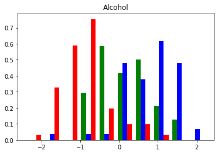

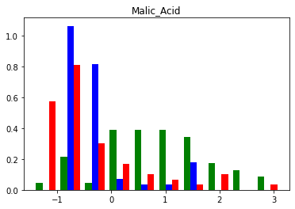

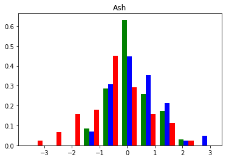

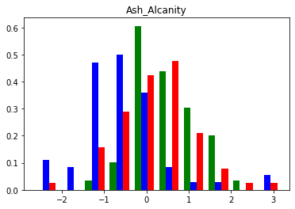

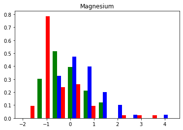

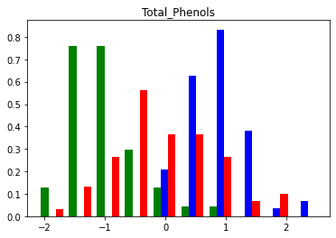

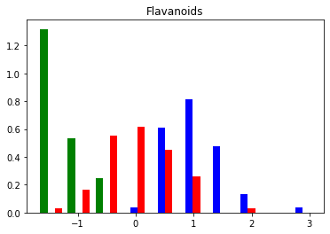

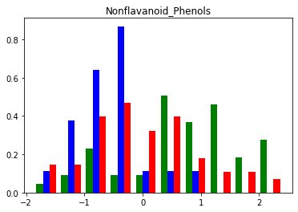

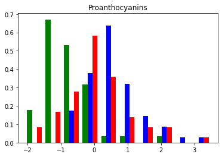

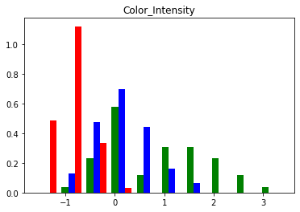

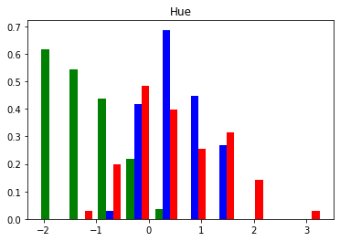

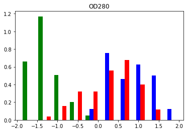

[1 more figures not shown]

```python
## Now I want to see how well it has separated the groups

wine_scaled['KMeans_Cluster'] = kmeans.labels_

wine_scaled.head()

## Plot histograms colored by cluster assignments

for col in wine_data.columns.tolist():
    cluster1 = wine_scaled.query('KMeans_Cluster == 0').loc[:,col]
    cluster2 = wine_scaled.query('KMeans_Cluster == 1').loc[:,col]
    cluster3 = wine_scaled.query('KMeans_Cluster == 2').loc[:,col]

    plt.hist([cluster1, cluster2, cluster3], color = ['green','blue','red'], density = True)

    plt.title(col)
    plt.show()
```

**Pairwise Analysis of Features Showing Greatest Separation**